# Data Visualization

#### Bar-Plots:

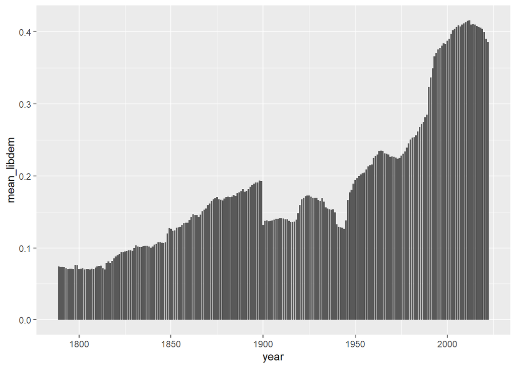

```r
ggplot(data=df_pol, aes(x = year, y = mean_libdem)) + geom_bar(stat = "identity") #bar plot requires specifying stat="identity" to use the value of each observation. The base of geom_bar is stat="count" in which R would count every observation per year. This is not what we want and would make sense since we only have one value per year, the mean.
```

#### Scatterplot:

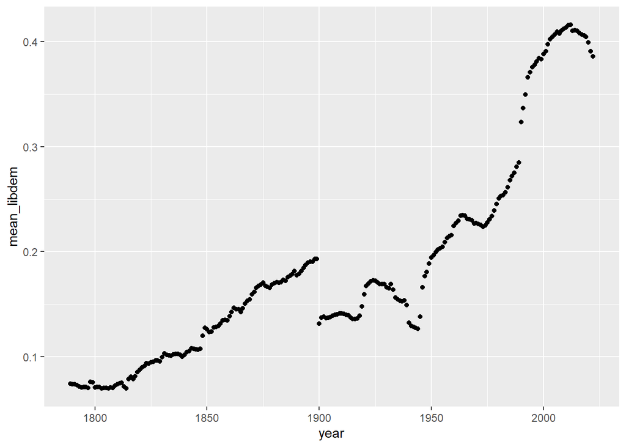

```r
ggplot(data=df_pol, aes(x = year, y = mean_libdem)) + geom_point()
```

#### Steps:

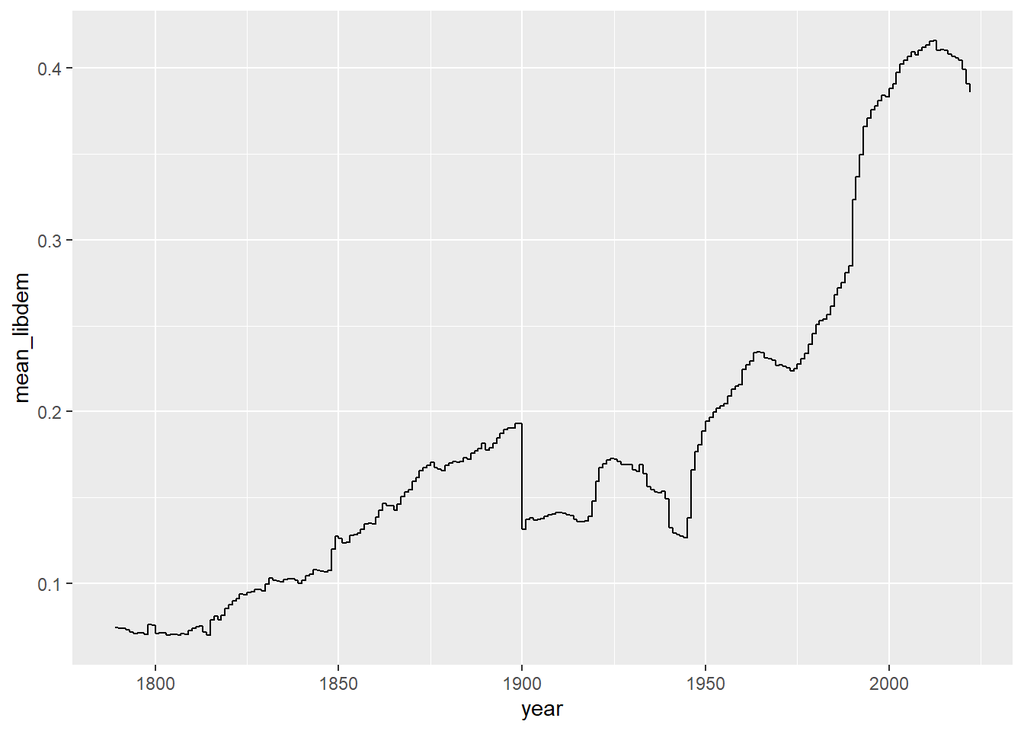

```r
ggplot(data=df_pol, aes(x = year, y = mean_libdem)) + geom_step()
```

These are some examples for simple plots using your data. And these examples also show us, that we do actually seem to find Huntington’s waves of democratization in the data! Sadly, they also show us that we appear to be in a fourth wave of autocratization which, however, is line with the theory.

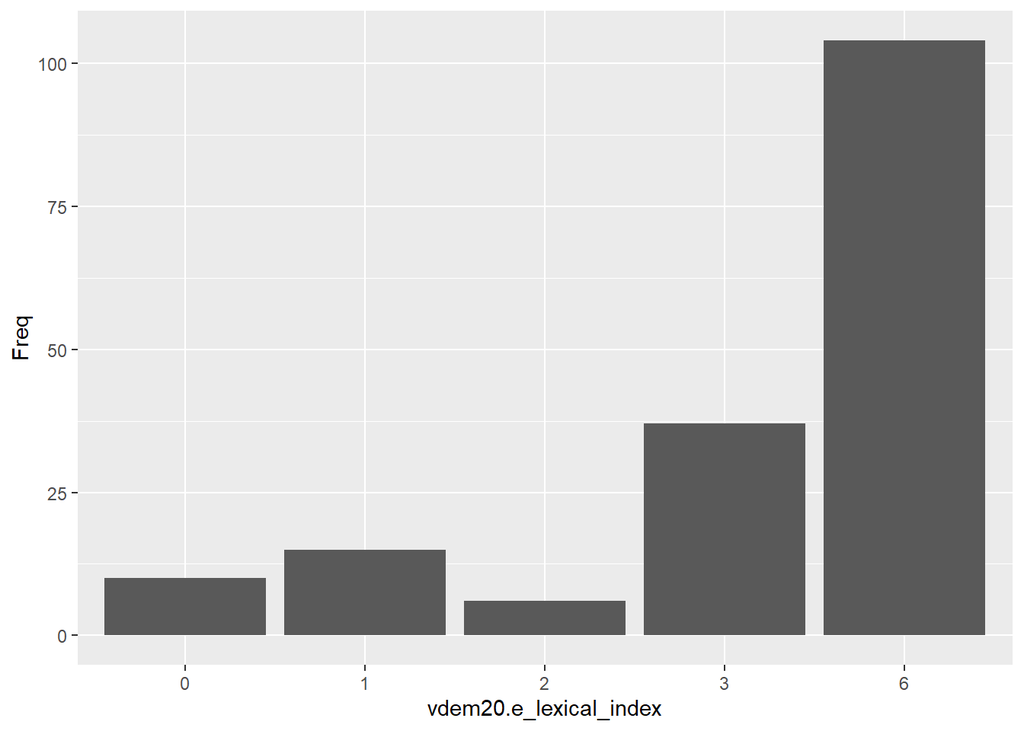

```r
vdem20 <- vdem %>% filter(year == 2020)

tab <- xtabs(~vdem20$e_lexical_index + vdem20$e_boix_regime)

t_df  <- data.frame(tab)
View(t_df)

ggplot(data = t_df, aes(x = vdem20.e_lexical_index, y = Freq)) + geom_col()
```

With a value of 6 standing for universal suffrage and competitive elections, this graph shows that democracy appears to be the most common form of government in the data, at least for the year 2020. Over a 100 countries are seen as fully democratic, while less than a hundred are categorized as less than fully democratic. Does this categorization also match with how Boix et al defined a democracy? To do so, we can add a third variable into the graphic. There are multiple ways to do so. One is to differentiate by color. Let us try that.

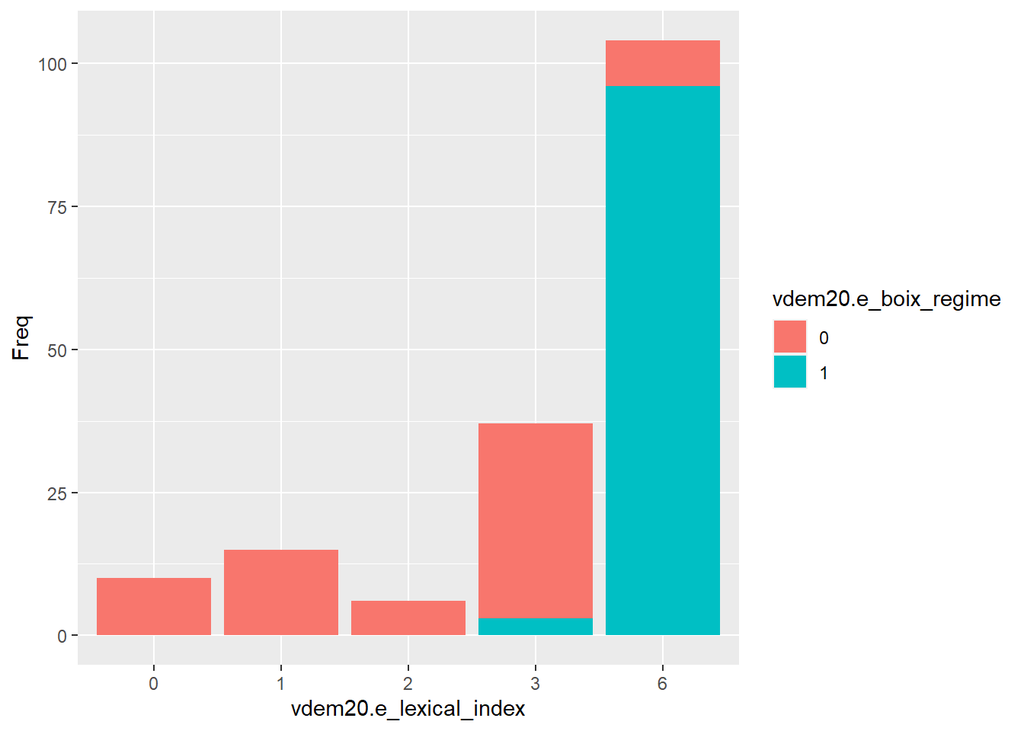

```r
ggplot(data = t_df, aes(x = vdem20.e_lexical_index, y = Freq, fill = vdem20.e_boix_regime)) + geom_col()
```

Interesting. These Indexes are very similar, however show some differences as well. With a democracy being coded as 1 in the index by Boix, not all countries coded as a perfect democracy by the Lexical Index were also coded as that by Boix. While on the other hand some variables coded as imperfect democracies by Lexical were coded as democratic by Boix. Thus, it is always very important to specifically define which definition of democracy, but generally any concept, your using in your papers, as results may vary based on that.

Alright, now let us get more… full scale! We now want to create a graphic that shows us how democracy has developed in different regions of the earth and which regime was the most prevalent in each year. To do so, we have to combine a few of the things we have learned so far. First, we have to create a variable that categorizes each country into a region.

```r
vdem2 <- vdem%>%
  select(year,v2x_regime,country_name) %>%
  mutate(regions_earth = case_when(country_name %in%c("Algeria", "Bahrain", "Egypt","Iran", "Iraq", "Israel", "Jordan", "Kuwait", "Lebanon", "Libya","Morocco","Oman", "Palestine/British Mandate", "Palestine/Gaza", "Palestine/West Bank","Qatar","Saudi Arabia","South Yemen","Syria","Turkey","Tunisia","Yemen","United Arab Emirates","Mauritania")~"MENA",

                               country_name %in%c("Austria","Belgium","France","Germany","Ireland","Luxembourg","Netherlands","Switzerland","United Kingdom","Canada","Mexico","United States of America","Anorra","Cyprus","Denmark","Finland","Greece","Iceland","Italy","Malta","Monaco","Norway","Portugal","Spain","Sweden","Denmark")~"Western Europe and North-America",
                               country_name
                               %in%c("Afghanistan","Kazakhstan","Kyrgyzstan","Tajikistan","Turkmenistan","Uzbekistan","Belarus","Croatia","Czech Republik","Estonia","Hungary","Lativa","Lithunia","Moldova","Poland","Russia","Slovakia","Slovenia","Ukraine","Albania","Bosnia and Herzegovina","Bulgaria","Kosovo","Montenegro","North Macedonia","Romania","Latvia","Lithuania","Serbia","Czech Republic")~"Eastern Europe and Central Asia",
                               country_name

%in%c("Barbados","Cuba","Dominican Republic","Guyana","Haiti","Jamaica","Suriname","Trinidad and Tobago","Costa Rica","El Salvador","Guatemala","Honduras","Nicaragua","Panama","Argentina","Bolivia","Brazil","Chile","Colombia","Ecuador","Paraguay","Peru","Uruguay","Venezuela")~"Latin-America and the Carribean",
                               country_name

%in%c("Armenia","Azerbaijan","Georgia","China","Hong Kong","Japan","Mongolia","North Korea","South Korea","Taiwan","Bangladesh","Bhutan","India","Maldives","Nepal","Pakistan","Sri Lanka","Burma/Myanmar","Cambodia","Indonesia","Laos","Malaysia","Philippines","Republic of Vietname","Singapore","Thailand","Timor-Leste","Vietnam","Fiji","Papua New Guinea","Solomon Islands","Vanuatu","Australia","New Zealand")~"Asia and the Pacific",
                               country_name

%in%c("Cameroon","Central African Republic","Chad","Democratic Republic of the Congo","Equatorial Guinea","Gabon","Republic of the Congo","Sao Tome and Principe","Burundi","Comoros","Djibouti","Eritrea","Ethiopia","Kenya","Malawia","Mauritius","Rwanda","Seychelles","Somalia","Somaliland","Sudan","Tanzania","Uganda","Zanzibar","Angola","Botswana","Eswatini","Lesotho","Madagascar","Mozambique","Namibia","South Africa","Zambia","Zimbabwe","Benin","Burkina Faso","Cape Verde","Ghana","Guinea","Guinea-Bissau","Ivory Coast","Liberia","Mali","Niger","Nigeria","Senegal","Sierra Leone","The Gambia","Togo","Malawi")~"Subsaharan Africa")
)
```

Lastly, we can plot. I chose a line graph, but you can use any of the previous graphs like `geom_col()` as long as they make sense in this scenario. Then, `facet_wrap()` was added. This neat little command allows us to add a fourth variable to differntiate by! so while x is the year, y is the frequency of regimes, and the color is the regime itself, we split the graphs into one graph for each region using `facet_wrap()`.

```r
vdem2$v2x_regime <- as.factor(vdem2$v2x_regime)

vdem2 <- na.omit(vdem2)

vdem3 <- vdem2 %>%
  group_by(year, regions_earth, v2x_regime) %>%
  summarise(count = n()) %>%
  group_by(year, regions_earth) %>%
  mutate(prop_reg = count / sum(count) * 100)
```

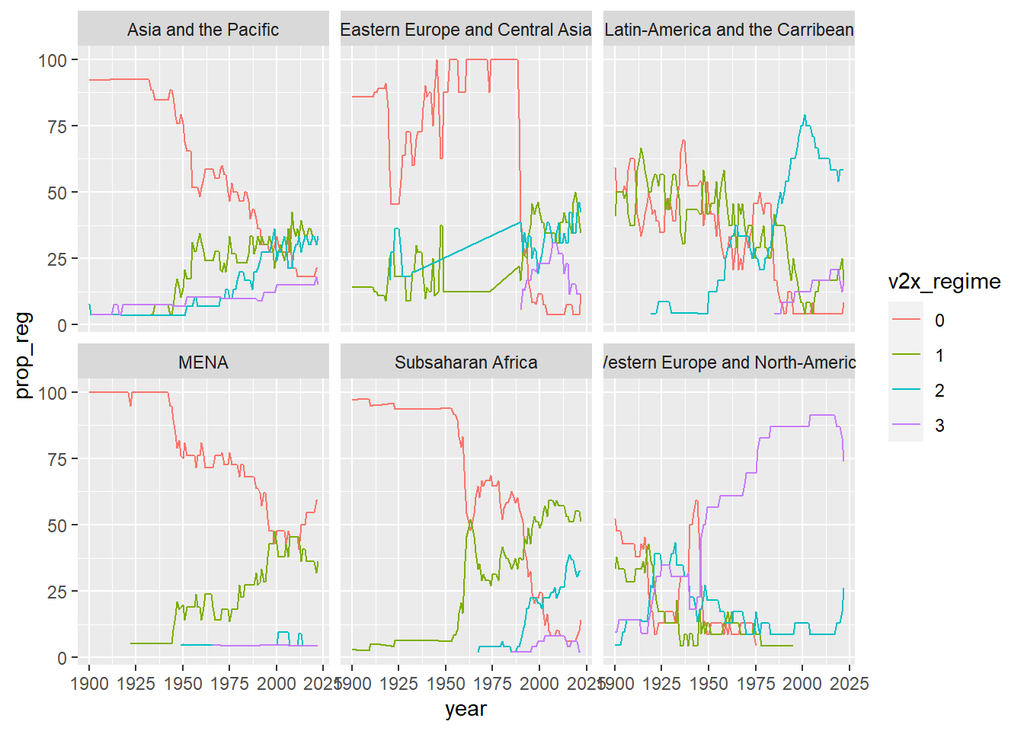

```r
ggplot(vdem3, aes(x = year, y = prop_reg, col = v2x_regime)) + geom_line() + facet_wrap(~regions_earth)
```

And here we have it! This graph shows to what percentage which type of regime was present in each region. Now, there are some minor problems caused by incomplete data, for example in 1950 to 1975 in eastern Europe, this graph is easily understandable and transports a lot of information…. however, what do the regime numbers mean? Can you really publish a graphic that has the variable names on the axis? What about a title?

Yes, all these problems can be fixed of course, by introducing labels! Easiest way to understand them is to look at an example. Look at this version of the code.

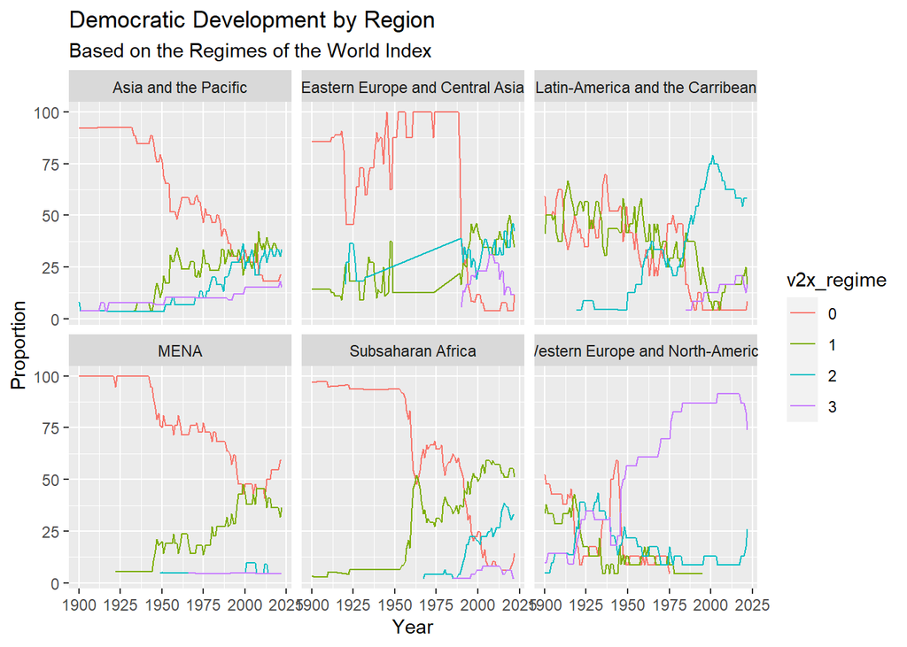

```r
ggplot(vdem3, aes(x = year, y = prop_reg, col = v2x_regime)) +
  geom_line() +
  labs(title = "Democratic Development by Region",
       subtitle = "Based on the Regimes of the World Index",
       x="Year",
       y="Proportion",
       fill = "Regime Type") +
  facet_wrap(~regions_earth)
```

Now we have some nice labels in our graph. But how about that legend?

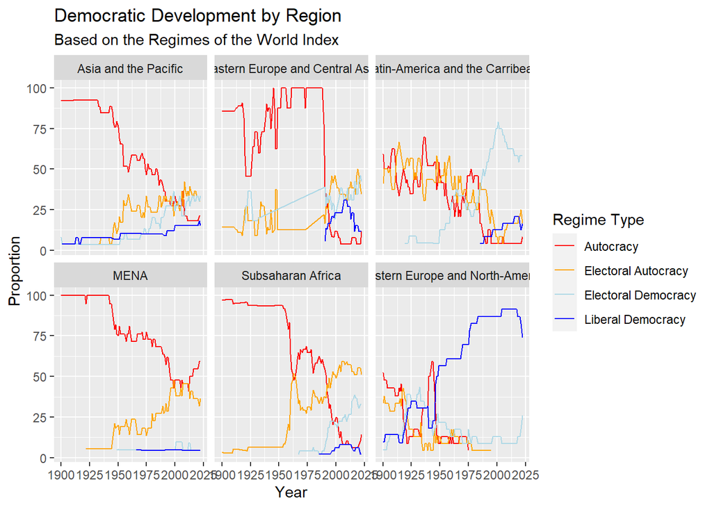

```r
ggplot(vdem3, aes(x = year, y = prop_reg, col = v2x_regime)) +
  geom_line() +
  labs(title = "Democratic Development by Region",
       subtitle = "Based on the Regimes of the World Index",
       x="Year",
       y="Proportion",
       color = "Regime Type") +
  facet_wrap(~regions_earth) +
  scale_color_manual(values = c("red", "orange", "lightblue", "blue"), breaks = c(0,1,2,3), labels =
                      c("Autocracy", "Electoral Autocracy", "Electoral Democracy", "Liberal Democracy"))
```

See what happened? With `scale_color_manual` we can manually change both the color and the labels of the graph and the legend. Color codes are a rabbit hole in ggplot. For some color variety, I recommend the following cheat sheet: [Cheat Sheet](https://www.nceas.ucsb.edu/sites/default/files/2020-04/colorPaletteCheatsheet.pdf).

## 4. Other Cosmetics

However, there are lot more things you can change about your graph. A few different things will be demonstrated here:

Changing the axis size

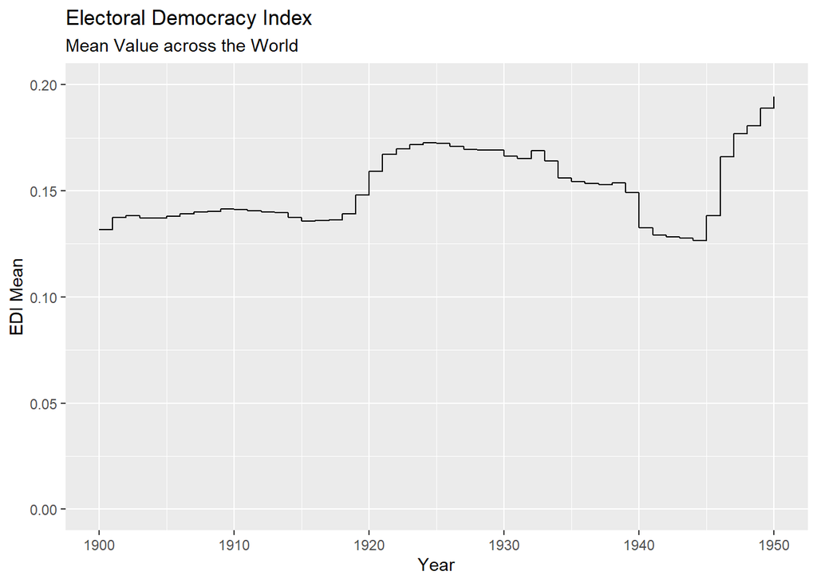

```r
ggplot(data=df_pol, aes(x = year, y = mean_libdem)) +
  geom_step() +
  labs(title = "Electoral Democracy Index",
       subtitle = "Mean Value across the World",
       y = "EDI Mean",
       x = "Year")+
  ylim(0,0.2) +   #If we want ggplot to limit the axis to values between 0 and 0.2
  xlim(1900,1950) #And only the years 1900 to 1950
```

We can change the theme of the whole graphic. GGPlot2 comes with a number of interesting themes.

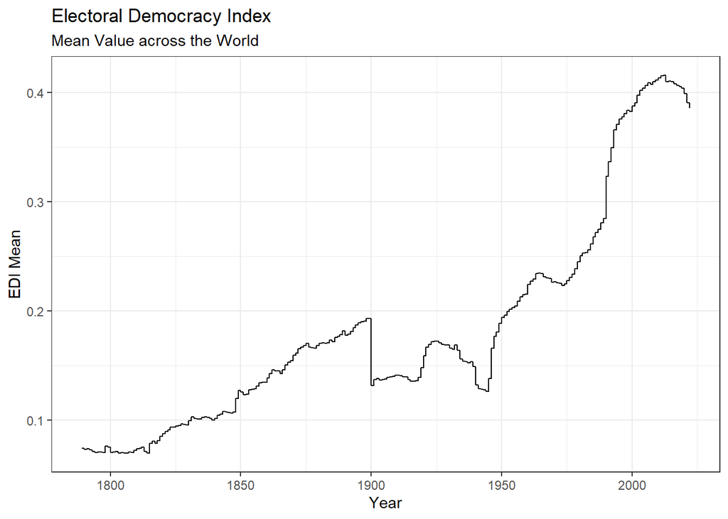

```r
ggplot(data=df_pol, aes(x = year, y = mean_libdem)) +
  geom_step() +
  labs(title = "Electoral Democracy Index",
       subtitle = "Mean Value across the World",
       y = "EDI Mean",
       x = "Year") +
  theme_bw()
```

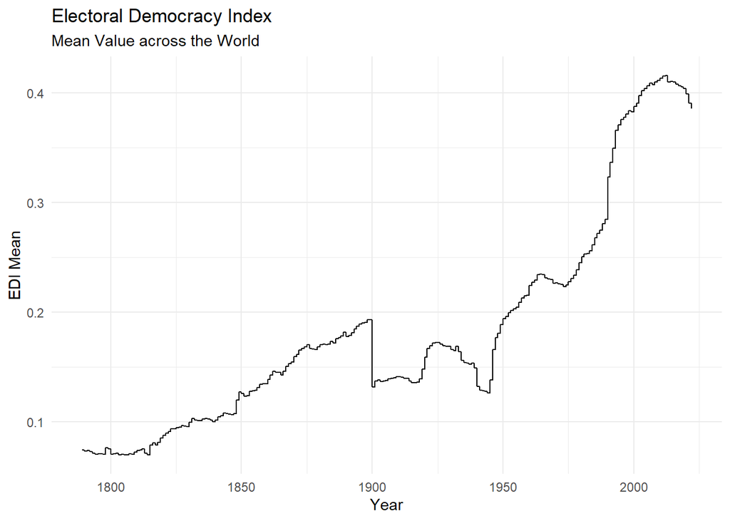

```r
ggplot(data=df_pol, aes(x = year, y = mean_libdem)) +
  geom_step() +
  labs(title = "Electoral Democracy Index",
       subtitle = "Mean Value across the World",
       y = "EDI Mean",
       x = "Year") +
  theme_minimal()
```

It does not make much sense in this context, but we can also simply flip the graph.

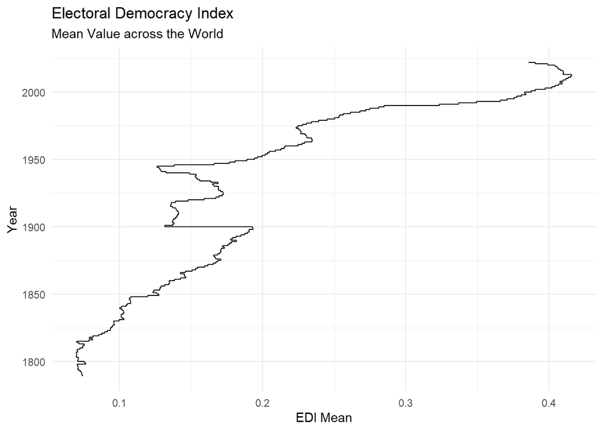

```r
ggplot(data=df_pol, aes(x = year, y = mean_libdem)) +
  geom_step() +
  labs(title = "Electoral Democracy Index",
       subtitle = "Mean Value across the World",
       y = "EDI Mean",
       x = "Year") +
  theme_minimal() +
  coord_flip()
```

## 5. Concluding Remarks

This should give you a good introduction to GGPlot2 and it’s logic. Once you have the base, you simply add every detail to your graphic step by step. There are a lot more small details you can adjust in your graphics, but there are too many to cover them all. The idea was to introduce you to the basics to start making your own graphics, that are presentable enough for publication. If you want to save your plots, you can simply click the export button in the plot window. For a cheat sheet, click this [Link](https://www.maths.usyd.edu.au/u/UG/SM/STAT3022/r/current/Misc/data-visualization-2.1.pdf).

In the next session you will learn about basic programming in R, which will make your life and code a lot easier and faster.

## Exercises: Make your own Plot

This one is bit harder. Using the V-Dem dataset, create boxplots that shows the development of gender equality (`v2clgencl`) for the years 1985 to 2005. Hint: Boxplots only work, if the years are coded as factors.

Now, add labels to the variables and give the graph a title. Give the graph the `classic` theme.